# Contrast tests with ART

Matthew Kay, Lisa A. Elkin, Jacob O. Wobbrock

2021-10-12

## Introduction

The aligned-rank transform (ART) allows for non-parametric analyses of variance ([Wobbrock et al. 2011](https://doi.org/10.1145/1978942.1978963)). But how should we do contrast tests with ART?

Contrasts involving levels of single factors, combinations of factors, or differences of differences across two factors can be performed by conducting those contrasts on a linear model aligned-and-ranked on the factors involved in the contrasts. This linear model may be one of the models used in the ART procedure, or it may require concatenating factors and constructing a new model, a procedure called *ART contrasts* or *ART-C* ([Elkin et al. 2021](https://dx.doi.org/10.1145/3472749.3474784)).

The `art.con()` function selects the appropriate model given a desired set of contrasts and then performs the requested contrasts. This page explains when and why a separate aligning-and-ranking procedure is needed to conduct contrasts and demonstrates how to conduct those contrasts using the `art.con()` function within the ART paradigm.

If you are not sure when/how to select the appropriate aligned-and-ranked linear model for a given contrast (i.e. when to use ART versus ART-C), the `art.con()` function demonstrated in this vignette will select the appropriate method given a contrast specification.

## Contents

1. Test Dataset: Description of the test data we will use to compare a linear model against ART
2. Contrast tests of main effects: Demo of conducting contrasts within a single factor (no interaction)
3. Tests of differences in pairwise combinations of levels between factors in interactions: This type of interaction contrast must be conducted with ART-C
4. Tests of differences of differences in interactions: This type of interaction contrast can be conducted with ART

## Libraries needed for this vignette

```r
library(dplyr)      #data_frame, %>%, filter, summarise, group_by
library(emmeans)    #emmeans, contrast
library(phia)       #testInteractions
library(tidyr)      #spread
library(ARTool)     #art, artlm
library(ggplot2)    #ggplot, stat_..., geom_..., etc
```

## Test dataset

Let’s generate some test data where we actually know what the effects are. Specifically,

```r
n_per_group = 150
df = tibble(
  X1 = factor(c(rep("A", n_per_group), rep("B", n_per_group))),
  X2 = factor(rep(c("C","D","E"), n_per_group * 2/3)),
  Y = rnorm(
    n_per_group * 2,
    (X1 == "B")
    + 2* (X2 == "D")
    + 2 * (X1 == "B" & X2 == "D")
    - 2 * (X1 == "A" & X2 == "D")
    + 2 * (X2 == "E")
  )
)
```

This is normally-distributed error with the same variance at all levels, so we can compare the results of ART and ART-C to a linear model, which will correctly estimate the effects.

I pre-ran the above code and saved it as `InteractionTestData` so that the text here is consistent:

```r
data(InteractionTestData, package = "ARTool")
df = InteractionTestData    #save some typing
```

The “true” means from the model look like this:

| X1 | X2 | Mean |
| --- | --- | --- |
| A | C or D | 0 |
| A | E | 2 |
| B | C | 1 |
| B | D | 5 |
| B | E | 3 |

Which we can see pretty well:

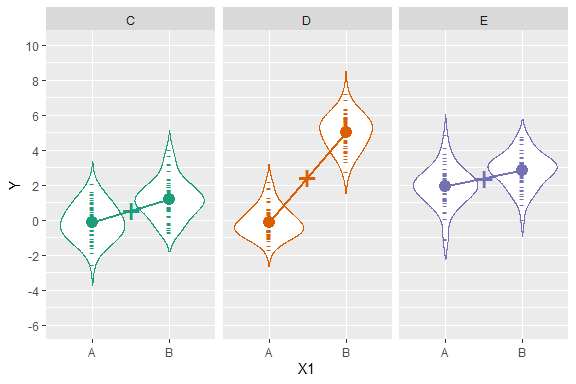

```r
# variant of the Dark2 colorbrewer scale with specific name mappings (so
# we can keep color -> name mapping consistent throughout this document)
palette = c("#1b9e77", "#d95f02", "#7570b3")
names(palette) = c("C", "D", "E")

df %>%
  ggplot(aes(x = X1, y = Y, color = X2)) +
  geom_violin(trim = FALSE, adjust = 1.5) +
  geom_point(pch = "-", size = 4) +
  stat_summary(fun = mean, geom = "point", size = 4) +
  stat_summary(aes(group = X2), fun = mean, geom = "line", size = 1) +
  stat_summary(aes(x = 1.5, group = NA), fun = mean, geom = "point", size = 9, pch = "+") +
  scale_y_continuous(breaks = seq(-6, 10, by = 2), minor_breaks = -6:10) +
  scale_color_manual(guide = FALSE, values = palette) +
  coord_cartesian(ylim = c(-6, 10)) +
  facet_grid(. ~ X2)
```

And “true” means for each level (averaging over the levels of the other factor):

| Level | Mean |
| --- | --- |
| X1 == A | 0.66666 |
| X1 == B | 3 |
| X2 == C | 0.5 |
| X2 == D | 2.5 |
| X2 == E | 2.5 |

Let’s fit a linear model:

```r
m.linear = lm(Y ~ X1*X2, data = df)
anova(m.linear)
```

```
## Analysis of Variance Table
##
## Response: Y
##            Df Sum Sq Mean Sq F value    Pr(>F)
## X1          1 445.50  445.50  439.44 < 2.2e-16 ***
## X2          2 236.44  118.22  116.61 < 2.2e-16 ***
## X1:X2       2 270.40  135.20  133.36 < 2.2e-16 ***
## Residuals 294 298.06    1.01
## ---
## Signif. codes:  0 '***' 0.001 '**' 0.01 '*' 0.05 '.' 0.1 ' ' 1
```

Now with ART:

```r
m.art = art(Y ~ X1*X2, data = df)
anova(m.art)
```

```
## Analysis of Variance of Aligned Rank Transformed Data
##
## Table Type: Anova Table (Type III tests)
## Model: No Repeated Measures (lm)
## Response: art(Y)
##
##         Df Df.res F value     Pr(>F)
## 1 X1     1    294  488.33 < 2.22e-16 ***
## 2 X2     2    294  114.35 < 2.22e-16 ***
## 3 X1:X2  2    294  145.65 < 2.22e-16 ***
## ---
## Signif. codes:   0 '***' 0.001 '**' 0.01 '*' 0.05 '.' 0.1 ' ' 1
```

Both have significance at all levels (expected given the number of samples and the “true” effects) and similar enough F values. The real question is whether/what kind of contrast tests make sense.

### Contrast tests of main effects

For the main effects, let’s look at contrast tests for the linear model:

```r
contrast(emmeans(m.linear, ~ X1), method = "pairwise")
```

```
##  contrast estimate    SE  df t.ratio p.value
##  A - B       -2.44 0.116 294 -20.963  <.0001
##
## Results are averaged over the levels of: X2
```

```r
contrast(emmeans(m.linear, ~ X2), method = "pairwise")
```

```
##  contrast estimate    SE  df t.ratio p.value
##  C - D     -1.9121 0.142 294 -13.428  <.0001
##  C - E     -1.8530 0.142 294 -13.013  <.0001
##  D - E      0.0592 0.142 294   0.415  0.9093
##
## Results are averaged over the levels of: X1
## P value adjustment: tukey method for comparing a family of 3 estimates
```

These are about right: The “true” effect for `A - B` is `-2.3333`, for `C - D` and `C - E` is `-2`, and for `D - E` is `0` (see table above). For ART, `artlm()` will return the appropriate linear model for single-factor contrasts, which we can then use with a library that does contrasts (such as `emmeans()`):

```r
# this works for single factors, though it is better (more general) to use
# artlm.con() or art.con() (see below)
contrast(emmeans(artlm(m.art, "X1"), ~ X1), method = "pairwise")
```

```
##  contrast estimate   SE  df t.ratio p.value
##  A - B        -137 6.19 294 -22.098  <.0001
##
## Results are averaged over the levels of: X2
```

```r
contrast(emmeans(artlm(m.art, "X2"), ~ X2), method = "pairwise")
```

```
##  contrast estimate   SE  df t.ratio p.value
##  C - D     -123.13 9.28 294 -13.272  <.0001
##  C - E     -119.81 9.28 294 -12.914  <.0001
##  D - E        3.32 9.28 294   0.358  0.9319
##
## Results are averaged over the levels of: X1
## P value adjustment: tukey method for comparing a family of 3 estimates
```

```r
contrast(emmeans(artlm.con(m.art, "X1"), ~ X1), method = "pairwise")
```

```
##  contrast estimate   SE  df t.ratio p.value
##  A - B        -137 6.19 294 -22.098  <.0001
##
## Results are averaged over the levels of: X2
```

```r
contrast(emmeans(artlm.con(m.art, "X2"), ~ X2), method = "pairwise")
```

```
##  contrast estimate   SE  df t.ratio p.value
##  C - D     -123.13 9.28 294 -13.272  <.0001
##  C - E     -119.81 9.28 294 -12.914  <.0001
##  D - E        3.32 9.28 294   0.358  0.9319
##
## Results are averaged over the levels of: X1
## P value adjustment: tukey method for comparing a family of 3 estimates
```

We can also use the shortcut function `art.con()`, which will perform the appropriate call to both `artlm.con()` and `emmeans()` for the desired contrast:

```r
art.con(m.art, "X1")
```

```
##  contrast estimate   SE  df t.ratio p.value
##  A - B        -137 6.19 294 -22.098  <.0001
##
## Results are averaged over the levels of: X2
```

```r
art.con(m.art, "X2")
```

```
##  contrast estimate   SE  df t.ratio p.value
##  C - D     -123.13 9.28 294 -13.272  <.0001
##  C - E     -119.81 9.28 294 -12.914  <.0001
##  D - E        3.32 9.28 294   0.358  0.9319
##
## Results are averaged over the levels of: X1
## P value adjustment: tukey method for comparing a family of 3 estimates
```

**Within a single factor** ART (i.e., `artlm()`) and ART-C (`artlm.con()`) are mathematically equivalent, so the contrast tests for ART and ART-C have the same results.

### Tests of differences in pairwise combinations of levels between factors in interactions

Now let’s look at tests of differences in combinations of levels between factors:

```r
contrast(emmeans(m.linear, ~ X1:X2), method = "pairwise")
```

```
##  contrast   estimate    SE  df t.ratio p.value
##  A C - B C -1.290161 0.201 294  -6.407  <.0001
##  A C - A D -0.000506 0.201 294  -0.003  1.0000
##  A C - B D -5.113912 0.201 294 -25.395  <.0001
##  A C - A E -2.044007 0.201 294 -10.150  <.0001
##  A C - B E -2.952089 0.201 294 -14.660  <.0001
##  B C - A D  1.289654 0.201 294   6.404  <.0001
##  B C - B D -3.823751 0.201 294 -18.988  <.0001
##  B C - A E -0.753846 0.201 294  -3.743  0.0030
##  B C - B E -1.661928 0.201 294  -8.253  <.0001
##  A D - B D -5.113406 0.201 294 -25.392  <.0001
##  A D - A E -2.043501 0.201 294 -10.148  <.0001
##  A D - B E -2.951583 0.201 294 -14.657  <.0001
##  B D - A E  3.069905 0.201 294  15.245  <.0001
##  B D - B E  2.161823 0.201 294  10.735  <.0001
##  A E - B E -0.908082 0.201 294  -4.509  0.0001
##
## P value adjustment: tukey method for comparing a family of 6 estimates
```

If we naively apply the ART procedure (using `artlm()`), we will get incorrect results:

```r
#DO NOT DO THIS!
contrast(emmeans(artlm(m.art, "X1:X2"), ~ X1:X2), method = "pairwise")
```

```
##  contrast  estimate   SE  df t.ratio p.value
##  A C - B C     76.9 12.4 294   6.202  <.0001
##  A C - A D    125.1 12.4 294  10.091  <.0001
##  A C - B D    -45.3 12.4 294  -3.650  0.0042
##  A C - A E    -12.1 12.4 294  -0.974  0.9258
##  A C - B E     87.2 12.4 294   7.030  <.0001
##  B C - A D     48.2 12.4 294   3.889  0.0017
##  B C - B D   -122.2 12.4 294  -9.853  <.0001
##  B C - A E    -89.0 12.4 294  -7.177  <.0001
##  B C - B E     10.3 12.4 294   0.828  0.9623
##  A D - B D   -170.4 12.4 294 -13.742  <.0001
##  A D - A E   -137.2 12.4 294 -11.066  <.0001
##  A D - B E    -38.0 12.4 294  -3.062  0.0288
##  B D - A E     33.2 12.4 294   2.676  0.0832
##  B D - B E    132.4 12.4 294  10.680  <.0001
##  A E - B E     99.2 12.4 294   8.004  <.0001
##
## P value adjustment: tukey method for comparing a family of 6 estimates
```

Compare these to the linear model: very different results!

The linear model tests are easy to interpret: they tell us the expected mean difference between combinations of levels.

The ART results are more difficult to interpret. Take `A,C - A,D`, which looks like this:

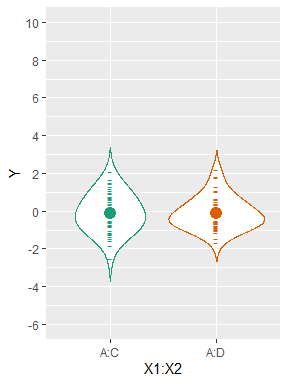

```r
df %>%
  filter(X1 == "A", X2 %in% c("C", "D")) %>%
  ggplot(aes(x = X1:X2, y = Y, color = X2)) +
  geom_violin(trim = FALSE, adjust = 1.5) +
  geom_point(pch = "-", size = 4) +
  stat_summary(fun = mean, geom = "point", size = 4) +
  scale_y_continuous(breaks = seq(-6, 10, by = 2), minor_breaks = -6:10) +
  scale_color_manual(guide = FALSE, values = palette) +
  coord_cartesian(ylim=c(-6,10))
```

The linear model correctly estimates this difference as approximately `0`, which is both the true effect and what we should expect from a visual inspection of the data. Unlike the linear model, the ART model gives us a statistically significant difference between `A,C` and `A,D`, which if we interpret in the same way as the linear model is obviously incorrect.

The key here is to understand that ART is reporting differences with the main effects subtracted out. That is, the `A,C - A,D` effect is something like the difference between this combination of levels if we first subtracted out the effect of `C - D`. We can see this if we take the ART estimate for `C - D` in the `emmeans` output for `X2` above (`-123.13`) and the ART estimate for `A,C - A,D` (`125.12`) here, we can get approximate an estimate of the difference (`-123.13 + 125.12 == 1.99`) that is consistent with the expected 0 (given the SE here).

The ART-C procedure was developed to align and rank data specifically for contrasts involving levels from any number of factors, and is available through `art.con()`:

```r
art.con(m.art, "X1:X2")
```

```
##  contrast  estimate   SE  df t.ratio p.value
##  A,C - A,D     1.96 8.91 294   0.220  0.9999
##  A,C - A,E  -100.96 8.91 294 -11.333  <.0001
##  A,C - B,C   -63.16 8.91 294  -7.090  <.0001
##  A,C - B,D  -205.76 8.91 294 -23.096  <.0001
##  A,C - B,E  -141.84 8.91 294 -15.921  <.0001
##  A,D - A,E  -102.92 8.91 294 -11.553  <.0001
##  A,D - B,C   -65.12 8.91 294  -7.310  <.0001
##  A,D - B,D  -207.72 8.91 294 -23.316  <.0001
##  A,D - B,E  -143.80 8.91 294 -16.141  <.0001
##  A,E - B,C    37.80 8.91 294   4.243  0.0004
##  A,E - B,D  -104.80 8.91 294 -11.764  <.0001
##  A,E - B,E   -40.88 8.91 294  -4.589  0.0001
##  B,C - B,D  -142.60 8.91 294 -16.007  <.0001
##  B,C - B,E   -78.68 8.91 294  -8.832  <.0001
##  B,D - B,E    63.92 8.91 294   7.175  <.0001
##
## P value adjustment: tukey method for comparing a family of 6 estimates
```

Like the linear model, `art.con()` correctly estimates the difference between `A,C - A,D` as approximately `0`. In fact, its results agree with the linear model for all contrasts conducted. (Note that the `art.con()` and linear model results appear in a different order).

The syntax used above is consistent with *term* syntax used by `artlm()`. `art.con()` also accepts the *formula* syntax accepted by `emmeans::emmeans()`. We can conduct the same contrasts as above using the following syntax:

```r
art.con(m.art, ~ X1*X2)
```

```
##  contrast  estimate   SE  df t.ratio p.value
##  A,C - A,D     1.96 8.91 294   0.220  0.9999
##  A,C - A,E  -100.96 8.91 294 -11.333  <.0001
##  A,C - B,C   -63.16 8.91 294  -7.090  <.0001
##  A,C - B,D  -205.76 8.91 294 -23.096  <.0001
##  A,C - B,E  -141.84 8.91 294 -15.921  <.0001
##  A,D - A,E  -102.92 8.91 294 -11.553  <.0001
##  A,D - B,C   -65.12 8.91 294  -7.310  <.0001
##  A,D - B,D  -207.72 8.91 294 -23.316  <.0001
##  A,D - B,E  -143.80 8.91 294 -16.141  <.0001
##  A,E - B,C    37.80 8.91 294   4.243  0.0004
##  A,E - B,D  -104.80 8.91 294 -11.764  <.0001
##  A,E - B,E   -40.88 8.91 294  -4.589  0.0001
##  B,C - B,D  -142.60 8.91 294 -16.007  <.0001
##  B,C - B,E   -78.68 8.91 294  -8.832  <.0001
##  B,D - B,E    63.92 8.91 294   7.175  <.0001
##
## P value adjustment: tukey method for comparing a family of 6 estimates
```

We can also manually conduct the contrasts with `emmeans::emmeans()` (or another library for running contrasts) by first extracting the linear model with `artlm.con()`. Note that the contrasts must be performed on the variable constructed by `artlm.con()` with the names of the factors involved concatenated together (`X1X2`):

```r
contrast(emmeans(artlm.con(m.art, "X1:X2"), ~ X1X2), method = "pairwise")
```

```
##  contrast  estimate   SE  df t.ratio p.value
##  A,C - A,D     1.96 8.91 294   0.220  0.9999
##  A,C - A,E  -100.96 8.91 294 -11.333  <.0001
##  A,C - B,C   -63.16 8.91 294  -7.090  <.0001
##  A,C - B,D  -205.76 8.91 294 -23.096  <.0001
##  A,C - B,E  -141.84 8.91 294 -15.921  <.0001
##  A,D - A,E  -102.92 8.91 294 -11.553  <.0001
##  A,D - B,C   -65.12 8.91 294  -7.310  <.0001
##  A,D - B,D  -207.72 8.91 294 -23.316  <.0001
##  A,D - B,E  -143.80 8.91 294 -16.141  <.0001
##  A,E - B,C    37.80 8.91 294   4.243  0.0004
##  A,E - B,D  -104.80 8.91 294 -11.764  <.0001
##  A,E - B,E   -40.88 8.91 294  -4.589  0.0001
##  B,C - B,D  -142.60 8.91 294 -16.007  <.0001
##  B,C - B,E   -78.68 8.91 294  -8.832  <.0001
##  B,D - B,E    63.92 8.91 294   7.175  <.0001
##
## P value adjustment: tukey method for comparing a family of 6 estimates
```

### Tests of *differences of differences* in interactions

You may also with to test *differences of differences*; e.g., for the interaction `X1:X2`, we might ask, is the difference `A - B` different when `X2 = C` compared to when `X2 = D`?. We can test this using the `interaction` argument to `art.con()`. When the `interaction` argument is supplied to art.con, differences of differences are tested on data that has been aligned-and-ranked using the **original** ART method (i.e., the data is **not** aligned-and-ranked using the ART-C method, as it is not necessary for these contrasts).

Before we test, let’s try to visualize what’s going on in just this interaction:

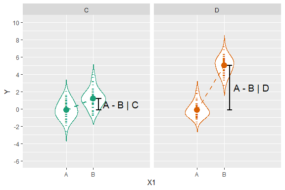

```r
plot_interaction_for_X2_levels = function(...) {
  x2_levels = c(...)
  df. = filter(df, X2 %in% x2_levels)

  X1_in_X2 = df. %>%
    group_by(X1, X2) %>%
    summarise(Y = mean(Y), .groups = "drop") %>%
    spread(X1, Y)

  print(
    ggplot(df., aes(x = X1, y = Y, color = X2)) +
      geom_violin(trim = FALSE, adjust = 1.5) +
      geom_point(pch = "-", size = 4) +
      stat_summary(fun = mean, geom = "point", size = 4) +
      stat_summary(aes(group = X2), fun = mean, geom = "line", size = 1, linetype = "dashed") +
      geom_errorbar(
        aes(x = 2.2, ymin = A, ymax = B, y = NULL),
        data = X1_in_X2, width = .19, size = 0.8, color = "black"
      ) +
      geom_text(
        aes(x = 2.35, y = (A + B)/2, label = paste("A - B |", X2)),
        data = X1_in_X2, hjust = 0, size = 5, color = "black"
      ) +
      scale_y_continuous(breaks = seq(-6, 10, by = 2), minor_breaks = -6:10) +
      scale_color_manual(guide = FALSE, values = palette[x2_levels]) +
      coord_cartesian(xlim = c(0, 3.5), ylim = c(-6,10)) +
      facet_grid(. ~ X2)
  )
}
plot_interaction_for_X2_levels("C", "D")
```

The true effect for `A - B | C` is -1, for `A - B | D` is -5, and for `(A - B | C) - (A - B | D)` is `(-1) - (-5) = 4`. Visually, we’re asking if the two dashed lines in the above plot are parallel. Equivalently, we’re asking if the vertical distance from the mean of A to the mean of B in the left panel (when X2 == C) is the same as the vertical distance between A and B in the right panel (when X2 == D). The true difference between these vertical distances (the “difference of a difference”) is 4, which is also about what we would estimate it to be by looking at the above plot.

We can get the estimate of this “difference of a difference” from the linear model by adding `interaction = TRUE` to the same call to `contrast` we made previously:

```r
contrast(emmeans(m.linear, ~ X1:X2), method = "pairwise", interaction = TRUE)
```

```
##  X1_pairwise X2_pairwise estimate    SE  df t.ratio p.value
##  A - B       C - D          3.823 0.285 294  13.425  <.0001
##  A - B       C - E         -0.382 0.285 294  -1.342  0.1808
##  A - B       D - E         -4.205 0.285 294 -14.766  <.0001
```

Here we can interpret the row `A - B C - D` as the difference between (`A - B | C`) and (`A - B | D`), which is estimated as `3.82` (close to the true effect of 4, see the plot above).

We can look at a similar plot for the row `A - B C - E`:

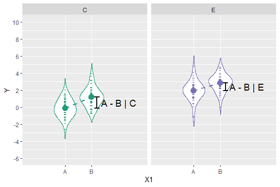

```r
plot_interaction_for_X2_levels("C", "E")
```

Here the true effect for `A - B | C` is -1, `A - B | E` is also -1, and `(A - B | C) - (A - B | E)` is `0`. Visually, this sample looks close to the true effects (the height of `A - B | C` is about the same as `A - B | E`). From the the row `A-B : C-E` above we can see that the estimate from the linear model is ~0, as we should hope.

A similar visual analysis finds the estimate for row `A - B D - E` (~ -4.2) also to be correct (true effect is -4):

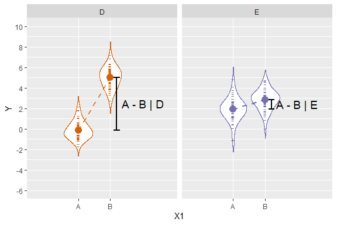

```r
plot_interaction_for_X2_levels("D", "E")
```

Now we look at these differences of differences in ART, using art.con():

```r
art.con(m.art, "X1:X2", interaction = TRUE)
```

```
##  X1_pairwise X2_pairwise estimate   SE  df t.ratio p.value
##  A - B       C - D          247.3 17.5 294  14.103  <.0001
##  A - B       C - E          -22.3 17.5 294  -1.274  0.2036
##  A - B       D - E         -269.6 17.5 294 -15.377  <.0001
```

This is equivalent to:

```r
contrast(emmeans(artlm(m.art, "X1:X2"), ~ X1:X2), method = "pairwise", interaction = TRUE)
```

```
##  X1_pairwise X2_pairwise estimate   SE  df t.ratio p.value
##  A - B       C - D          247.3 17.5 294  14.103  <.0001
##  A - B       C - E          -22.3 17.5 294  -1.274  0.2036
##  A - B       D - E         -269.6 17.5 294 -15.377  <.0001
```

And we see *t* values consistent with the linear model, and consistent estimates (given the standard error). These types of comparisons work under ART because they do not involve coefficients of main effects (see the description of these tests in `vignette("phia")`), thus are consistent even when ART has stripped out the main effects.

If you prefer the `phia` package, the code to run the equivalent tests using the `testInteractions` function in `phia` instead of using `emmeans` is:

```r
testInteractions(artlm(m.art, "X1:X2"), pairwise = c("X1","X2"))
```

```
## F Test:
## P-value adjustment method: holm
##             Value  Df Sum of Sq        F Pr(>F)
## A-B : C-D  247.28   1    764342 198.8827 <2e-16 ***
## A-B : C-E  -22.34   1      6238   1.6232 0.2036
## A-B : D-E -269.62   1    908687 236.4412 <2e-16 ***
## Residuals         294   1129896
## ---
## Signif. codes:  0 '***' 0.001 '**' 0.01 '*' 0.05 '.' 0.1 ' ' 1
```

While `emmeans()` uses *t* tests in this case, `testInteractions()` gives the result of equivalent *F* tests with one numerator degree of freedom (an *F* test with $F(1,\nu) = f$ is equivalent to a two-sided *t* test with $t(\nu) = \sqrt{f}$). I prefer the *t* test in this case because the *t* value preserves the direction of the effect (its sign) and is more amenable to calculating interpretable (ish) effect sizes like Cohen’s *d*. For an example of the latter, see `vignette(“art-effect-size”)`.